# Instances and ports

GDS allows the cell to be used once by the memory and instance or make multiple instances of the cell

As you build cells you can invoke other cells. Adding an instance is like having a pointer to a cell.

The GDSII specification allows the use of instances and similarly kfactory uses them (with the `create_inst()` function). What is an instance? Simply put: **An instance does not contain any geometry. It only *points* to an existing geometry**.

Say you have a ridiculously large polygon with 100 billion vertices that you call it BigPolygon. It is huge, and you need to use it in your design 250 times. Well, a single copy of BigPolygon takes up 1MB of memory, so you do not want to make 250 copies of it You can instead *instances* the polygon 250 times. Each instance only uses a few bytes of memory -- It only needs to know the memory address of the BigPolygon, alongside its position, rotation and mirror. This way, you can keep one copy of BigPolygon and use it again and again.

You can start by making a blank `KFactory` and add a single polygon to it.

```python
import kfactory as kf

# Define Layers

class LayerInfos(kf.LayerInfos):
    WG: kf.kdb.LayerInfo = kf.kdb.LayerInfo(1,0)
    WGEX: kf.kdb.LayerInfo = kf.kdb.LayerInfo(2,0) # WG Exclude
    CLAD: kf.kdb.LayerInfo = kf.kdb.LayerInfo(4,0) # cladding
    FLOORPLAN: kf.kdb.LayerInfo = kf.kdb.LayerInfo(10,0)

# Make the layout object aware of the new layers:
LAYER = LayerInfos()
kf.kcl.infos = LAYER
```

import kfactory as kf # Define Layers class LayerInfos(kf.LayerInfos): WG: kf.kdb.LayerInfo = kf.kdb.LayerInfo(1,0) WGEX: kf.kdb.LayerInfo = kf.kdb.LayerInfo(2,0) # WG Exclude CLAD: kf.kdb.LayerInfo = kf.kdb.LayerInfo(4,0) # cladding FLOORPLAN: kf.kdb.LayerInfo = kf.kdb.LayerInfo(10,0) # Make the layout object aware of the new layers: LAYER = LayerInfos() kf.kcl.infos = LAYER

```python
# Create a blank Cell
p = kf.KCell()

# Add a polygon
xpts = [0, 0, 5, 6, 9, 12]
ypts = [0, 1, 1, 2, 2, 0]
p.shapes(p.kcl.find_layer(2, 0)).insert(
    kf.kdb.DPolygon([kf.kdb.DPoint(x, y) for x, y in zip(xpts, ypts)])
)

# Plot the cell with the polygon in it
p
```

[output not shown]

# Create a blank Cell p = kf.KCell() # Add a polygon xpts = [0, 0, 5, 6, 9, 12] ypts = [0, 1, 1, 2, 2, 0] p.shapes(p.kcl.find_layer(2, 0)).insert( kf.kdb.DPolygon([kf.kdb.DPoint(x, y) for x, y in zip(xpts, ypts)]) ) # Plot the cell with the polygon in it p

Now, you want to reuse this polygon repeatedly without creating multiple copies of it.

To do so, you need to make a second blank `Cell`, this time named `c`.

In this new cell you *instance* our cell `p` which contains our polygon.

```python
c = kf.KCell(name="Cell_with_instances")  # Create a new blank cell
poly_ref = c.create_inst(p)  # instance the cell "p" that has the polygon in it
c
```

[output not shown]

c = kf.KCell(name="Cell_with_instances") # Create a new blank cell poly_ref = c.create_inst(p) # instance the cell "p" that has the polygon in it c

You just made a copy of your polygon -- but remember, you did not actually make a second polygon, you just made an instance (aka pointer) to the original polygon. Let us now add two more instances to `c`:

```python
poly_ref2 = c.create_inst(p)  # instance the Cell "p" that has the polygon in it
poly_ref3 = c.create_inst(p)  # instance the Cell "p" that has the polygon in it
c
```

[output not shown]

poly_ref2 = c.create_inst(p) # instance the Cell "p" that has the polygon in it poly_ref3 = c.create_inst(p) # instance the Cell "p" that has the polygon in it c

```python
poly_ref2.transform(
    kf.kdb.DCplxTrans(1, 15, False, 0, 0)
)  # Rotate the 2nd instance we made 15 degrees
poly_ref3.transform(
    kf.kdb.DCplxTrans(1, 30, False, 0, 0)
)  # Rotate the 3rd instance we made 30 degrees
c
```

poly_ref2.transform( kf.kdb.DCplxTrans(1, 15, False, 0, 0) ) # Rotate the 2nd instance we made 15 degrees poly_ref3.transform( kf.kdb.DCplxTrans(1, 30, False, 0, 0) ) # Rotate the 3rd instance we made 30 degrees c

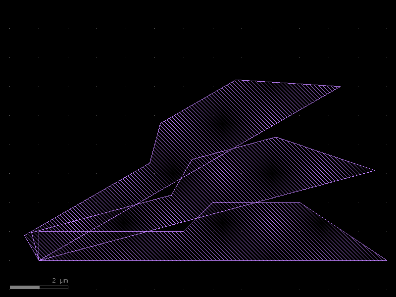

Now you are getting somewhere! You have only had to make the polygon once, but you are able to reuse it as many times as you want.

## Modifying the instances

What happens when you change the original geometry of the instance? In your case, your instances in `c` all point to the cell `p`, the cell with the original polygon. Let us now try adding a second polygon to `p`. First, you add the second polygon and make sure `P` looks like you expect it to:

```python
# Add a 2nd polygon to "p"
xpts = [14, 14, 16, 16]
ypts = [0, 2, 2, 0]
p.shapes(p.kcl.find_layer(1, 0)).insert(
    kf.kdb.DPolygon([kf.kdb.DPoint(x, y) for x, y in zip(xpts, ypts)])
)
p
```

# Add a 2nd polygon to "p" xpts = [14, 14, 16, 16] ypts = [0, 2, 2, 0] p.shapes(p.kcl.find_layer(1, 0)).insert( kf.kdb.DPolygon([kf.kdb.DPoint(x, y) for x, y in zip(xpts, ypts)]) ) p

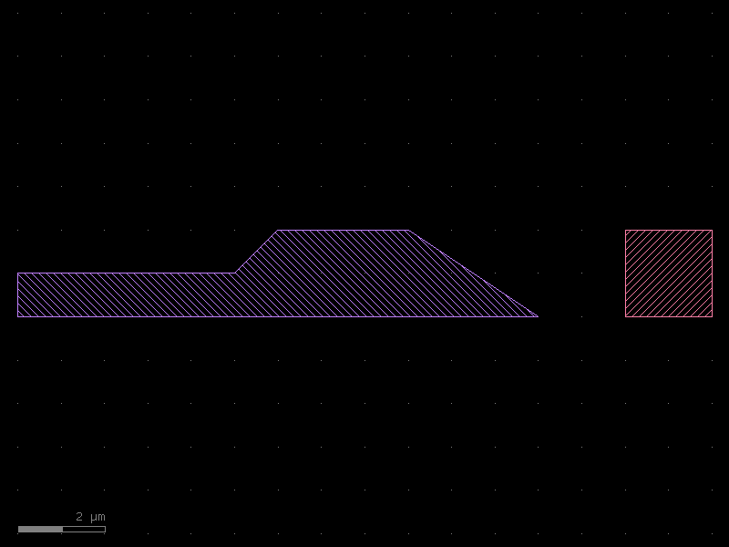

That looks good. Now let us find out what happened to `c` which contains the three instances. Keep in mind that you have not modified `c` or executed any functions/operations on `c` -- all you have done is modify `p`.

```python
c
```

c

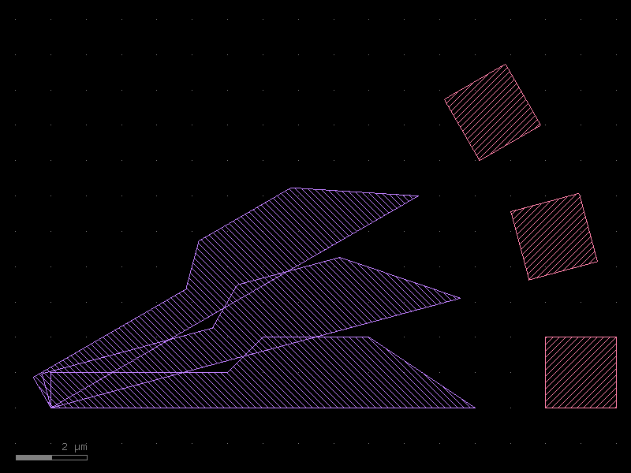

**When you modify the original geometry, all of the instances automatically reflect the modifications.** This is very powerful, because you can use this to make very complicated designs from relatively simple elements in a computation- and memory-efficient way.

```python
c2 = kf.KCell(name="array_sample")  # Create a new blank Cell
d_ref1 = c2.create_inst(c)  # instance the cell "c" that has the 3 instances in it
d_ref2 = c2 << c  # Use the "<<" operator to create a 2nd instance to c
d_ref3 = c2 << c  # Use the "<<" operator to create a 3rd instance to c

d_ref1.transform(kf.kdb.DTrans(20.0, 0.0))
d_ref2.transform(kf.kdb.DTrans(40.0, 0.0))

c2
```

c2 = kf.KCell(name="array_sample") # Create a new blank Cell d_ref1 = c2.create_inst(c) # instance the cell "c" that has the 3 instances in it d_ref2 = c2 << c # Use the "<<" operator to create a 2nd instance to c d_ref3 = c2 << c # Use the "<<" operator to create a 3rd instance to c d_ref1.transform(kf.kdb.DTrans(20.0, 0.0)) d_ref2.transform(kf.kdb.DTrans(40.0, 0.0)) c2

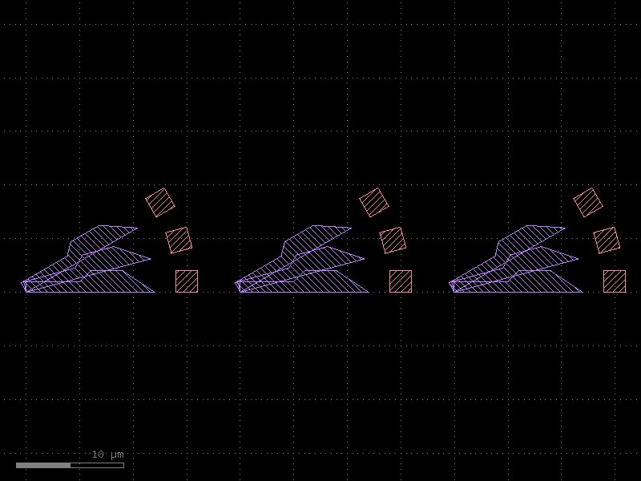

As you have seen you have two ways to add an instance to our cell:

1. Create the instance and add it to the cell

```python
c = kf.KCell(name="instance_sample")
w = kf.cells.straight.straight(length=10, width=0.6, layer=LAYER.WG)
wr = kf.kdb.CellInstArray(w.kdb_cell, kf.kdb.Trans.R0)
c.insert(wr)
c
```

c = kf.KCell(name="instance_sample") w = kf.cells.straight.straight(length=10, width=0.6, layer=LAYER.WG) wr = kf.kdb.CellInstArray(w.kdb_cell, kf.kdb.Trans.R0) c.insert(wr) c

[figure not shown]

2. Alternatively, you can do it in a single line

```python
c = kf.KCell(name="instance_sample_shorter_syntax")
wr = c << kf.cells.straight.straight(length=10, width=0.6, layer=LAYER.WG)
c
```

c = kf.KCell(name="instance_sample_shorter_syntax") wr = c << kf.cells.straight.straight(length=10, width=0.6, layer=LAYER.WG) c

[figure not shown]

in both cases you can move the instance `wr` after creating it

```python
c = kf.KCell(name="two_instances")
wr1 = c << kf.cells.straight.straight(length=10, width=0.6, layer=LAYER.WG)
wr2 = c << kf.cells.straight.straight(length=10, width=0.6, layer=LAYER.WG)
wr2.transform(kf.kdb.DTrans(0.0, 10.0))
c.add_ports(wr1.ports, prefix="top_")
c.add_ports(wr2.ports, prefix="bot_")
```

c = kf.KCell(name="two_instances") wr1 = c << kf.cells.straight.straight(length=10, width=0.6, layer=LAYER.WG) wr2 = c << kf.cells.straight.straight(length=10, width=0.6, layer=LAYER.WG) wr2.transform(kf.kdb.DTrans(0.0, 10.0)) c.add_ports(wr1.ports, prefix="top_") c.add_ports(wr2.ports, prefix="bot_")

```python
c.ports
```

c.ports

```
["DPort(self.name='top_o1', self.width=0.6, trans=r180 *1 0,0, layer=WG (1/0), port_type=optical)", "DPort(self.name='top_o2', self.width=0.6, trans=r0 *1 10,0, layer=WG (1/0), port_type=optical)", "DPort(self.name='bot_o1', self.width=0.6, trans=r180 *1 0,10, layer=WG (1/0), port_type=optical)", "D…
```

You can also auto_rename ports using gdsfactory default convention, in which ports are numbered clockwise starting from the bottom left.

```python
c.auto_rename_ports()
```

c.auto_rename_ports()

```python
c.ports
```

c.ports

```
["DPort(self.name='o1', self.width=0.6, trans=r180 *1 0,0, layer=WG (1/0), port_type=optical)", "DPort(self.name='o4', self.width=0.6, trans=r0 *1 10,0, layer=WG (1/0), port_type=optical)", "DPort(self.name='o2', self.width=0.6, trans=r180 *1 0,10, layer=WG (1/0), port_type=optical)", "DPort(self.na…
```

```python
c
```

c

[figure not shown]

## Arrays of instances

Let us make a new Cell and put a big array of our cell `c` in it:

```python
import kfactory as kf

print(kf.__version__)
c = kf.cells.straight.straight(length=10, width=0.6, layer=LAYER.WG)
c3 = kf.KCell()  # Create a new blank Cell
aref = c3.create_inst(
    c, na=1, nb=3, a=(20000, 0), b=(0, 15000)
)  # Create three copies of the component named 'c' and arrange them in a vertical stack

c3.add_ports(aref.ports)
c3.draw_ports()
c3.plot()
```

import kfactory as kf print(kf.__version__) c = kf.cells.straight.straight(length=10, width=0.6, layer=LAYER.WG) c3 = kf.KCell() # Create a new blank Cell aref = c3.create_inst( c, na=1, nb=3, a=(20000, 0), b=(0, 15000) ) # Create three copies of the component named 'c' and arrange them in a vertical stack c3.add_ports(aref.ports) c3.draw_ports() c3.plot()

```
2.5.1
```

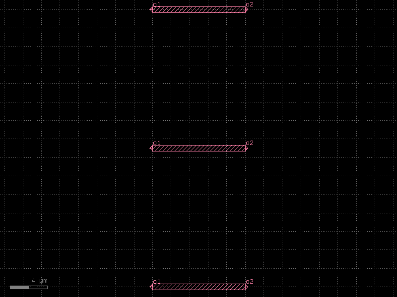

You can still access the ports for each instance

```python
aref['o1', 0, 1]
```

aref['o1', 0, 1]

```
Port(self.name='o1', self.width=600, trans=r180 *1 0,15, layer=WG (1/0), port_type=optical)
```

```python
c.ports
```

c.ports

```
["DPort(self.name='o1', self.width=0.6, trans=r180 *1 0,0, layer=WG (1/0), port_type=optical)", "DPort(self.name='o2', self.width=0.6, trans=r0 *1 10,0, layer=WG (1/0), port_type=optical)"]
```

## Connect the instances

We have seen that once you create a instance you can manipulate the instance to move it to a location. Here we are going to connect that instance to a port. Remember that we follow the rule that a certain instance `source` connects to a `destination` port.

```python
c = kf.KCell()
bend = kf.cells.euler.bend_euler(radius=5, width=1, layer=LAYER.WG)
b1 = c << bend
b2 = c << bend
b2.connect("o1", b1.ports["o2"])
c
```

c = kf.KCell() bend = kf.cells.euler.bend_euler(radius=5, width=1, layer=LAYER.WG) b1 = c << bend b2 = c << bend b2.connect("o1", b1.ports["o2"]) c

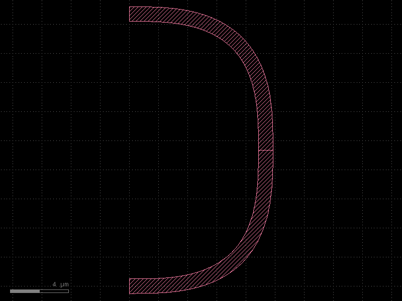

```python
c = kf.KCell()
b1 = c << kf.cells.euler.bend_euler(radius=5, width=1, layer=LAYER.WG, angle=30)
b2 = c << kf.cells.euler.bend_euler(radius=5, width=1, layer=LAYER.WG, angle=30)
b2.connect("o1", b1.ports["o2"])
c.show()
c
```

c = kf.KCell() b1 = c << kf.cells.euler.bend_euler(radius=5, width=1, layer=LAYER.WG, angle=30) b2 = c << kf.cells.euler.bend_euler(radius=5, width=1, layer=LAYER.WG, angle=30) b2.connect("o1", b1.ports["o2"]) c.show() c

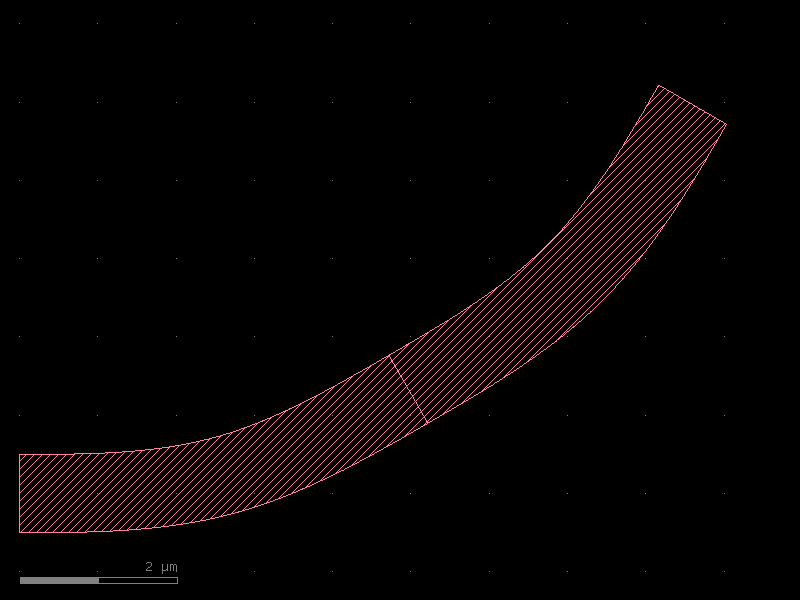

[figure not shown]

This non-manhattan connect will create less than 1nm gaps that you can fix by flattening the references.

```python
c = kf.KCell()
b1 = c << kf.cells.euler.bend_euler(radius=5, width=1, layer=LAYER.WG, angle=30)
b2 = c << kf.cells.euler.bend_euler(radius=5, width=1, layer=LAYER.WG, angle=30)
b2.connect("o1", b1.ports["o2"])
b2.flatten()
c.show()
c
```

c = kf.KCell() b1 = c << kf.cells.euler.bend_euler(radius=5, width=1, layer=LAYER.WG, angle=30) b2 = c << kf.cells.euler.bend_euler(radius=5, width=1, layer=LAYER.WG, angle=30) b2.connect("o1", b1.ports["o2"]) b2.flatten() c.show() c

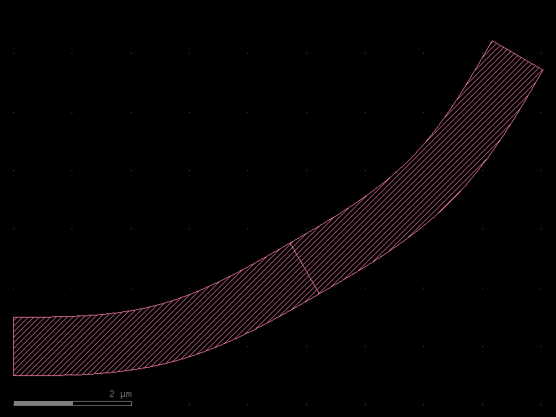

[figure not shown]

## Port naming

You have the freedom to name the ports as you want, and you can use `c.auto_rename_ports` to rename them later on. Here is the default naming convention. Ports are numbered clock-wise starting from the bottom left corner. Optical ports have `o` prefix and Electrical ports `e` prefix.

Here is the default one we use (clockwise starting from bottom left west facing port)

```
             3   4
             |___|_
         2 -|      |- 5
            |      |
         1 -|______|- 6
             |   |
             8   7
```

## pins

You can add pins (port markers) to each port. Each foundry PDK does this differently, so gdsfactory supports all of them.

- square with port inside the cell
- square centered (half inside, half outside cell)
- triangular
- path (SiEPIC)

by default `KCell.show()` will add triangular pins, so you can see the direction of the port in KLayout.

```python
c = kf.cells.euler.bend_euler(radius=5, width=1, layer=LAYER.WG, angle=90)
c.draw_ports()
c
```

c = kf.cells.euler.bend_euler(radius=5, width=1, layer=LAYER.WG, angle=90) c.draw_ports() c

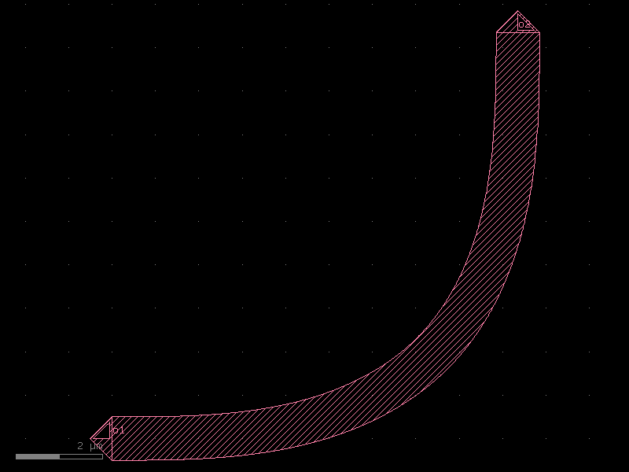